# EAS508-Q9

Question 9

This exercise involves the `Auto` data set available as `Auto.csv` available on the textbook website. Remove the missing values from the data.

```r
# Loading data and removing missing values.

Auto <- read.csv("Auto.csv", header = TRUE, na.strings = "?", stringsAsFactors = T)
Auto <- na.omit(Auto)
dim(Auto)
```

```
[1] 392   9
```

```r
# Head of data

head(Auto)
```

|  | mpg | cylinders | displacement | horsepower | weight | acceleration | year | origin | name |
| --- | --- | --- | --- | --- | --- | --- | --- | --- | --- |
| 1 | 18 | 8 | 307 | 130 | 3504 | 12.0 | 70 | 1 | chevrolet chevelle malibu |
| 2 | 15 | 8 | 350 | 165 | 3693 | 11.5 | 70 | 1 | buick skylark 320 |
| 3 | 18 | 8 | 318 | 150 | 3436 | 11.0 | 70 | 1 | plymouth satellite |
| 4 | 16 | 8 | 304 | 150 | 3433 | 12.0 | 70 | 1 | amc rebel sst |
| 5 | 17 | 8 | 302 | 140 | 3449 | 10.5 | 70 | 1 | ford torino |
| 6 | 15 | 8 | 429 | 198 | 4341 | 10.0 | 70 | 1 | ford galaxie 500 |

a. Which of the predictors are quantitative, and which are qualitative?

```
mpg, cylinders, displacement, horsepower, weight, accelaration, year are quantitative predictors.

name, origin are qualitative predictors.
```

2. What is the *range* of each quantitative predictor?

```r
#Grouping together all the quantitative predictors
quantitative_predictors <- which(names(Auto) %in%
                                   c("mpg","cylinders","displacement","horsepower", "weight","acceleration","year"))

quantitative_predictors
```

```
[1] 1 2 3 4 5 6 7
```

```r
# Find the range for all using sapply and range function.

sapply(Auto[, quantitative_predictors], range)
```

```
      mpg cylinders displacement horsepower weight acceleration year
[1,]  9.0         3           68         46   1613          8.0   70
[2,] 46.6         8          455        230   5140         24.8   82
```

3. What is the mean and standard deviation of each quantitative predictor?

```r
# FInd the mean for all quantitative predictors using mean function.

sapply(Auto[, quantitative_predictors], mean)
```

```
         mpg    cylinders displacement   horsepower       weight acceleration         year
   23.445918     5.471939   194.411990   104.469388  2977.584184    15.541327    75.979592
```

```r
# Find the standard deviation for all quantitative predictors using sd function.

sapply(Auto[, quantitative_predictors], sd)
```

```
         mpg    cylinders displacement   horsepower       weight acceleration         year
    7.805007     1.705783   104.644004    38.491160   849.402560     2.758864     3.683737
```

4. Now remove the 10th through 85th observations. What is the range, mean, and standard deviation of each predictor in the subset of the data that remains?

```r
#Mean after removing 10-85th observations

sapply(Auto[-seq(10, 85), quantitative_predictors], mean)
```

```
         mpg    cylinders displacement   horsepower       weight acceleration         year
   24.404430     5.373418   187.240506   100.721519  2935.971519    15.726899    77.145570
```

```r
#Standard deviation after removing 10-85th observations

sapply(Auto[-seq(10, 85), quantitative_predictors], sd)
```

```
         mpg    cylinders displacement   horsepower       weight acceleration         year
    7.867283     1.654179    99.678367    35.708853   811.300208     2.693721     3.106217
```

5. Using the full data set, investigate the predictors graphically, using scatterplots or other tools of your choice. Create some plots highlighting the relationships among the predictors. Comment on your findings.

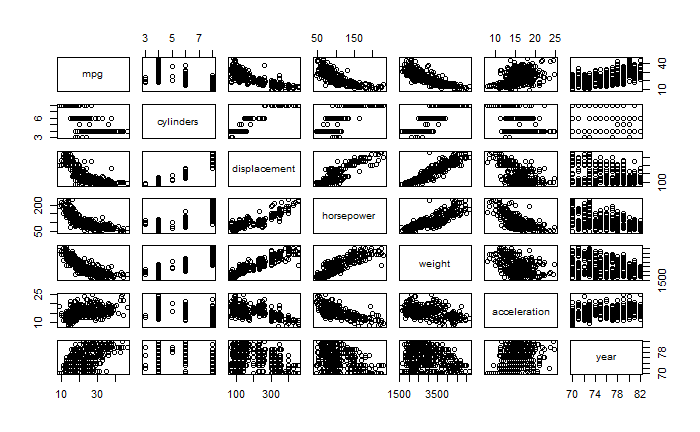

```r
# Scatter plot matrix for all the quantitative predictors.

pairs(Auto[ , quantitative_predictors])
```

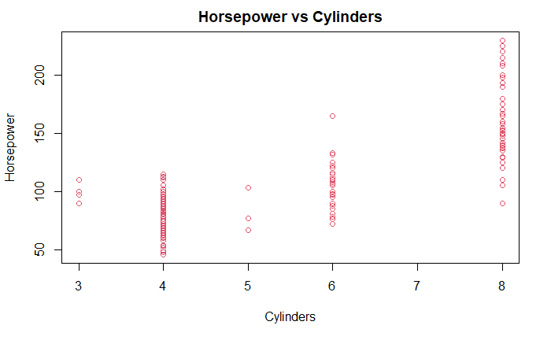

```r
# Relation between cylinders and horsepower

plot(Auto$horsepower~Auto$cylinders, col = 2, main = "Horsepower vs Cylinders", xlab = "Cylinders", ylab = "Horsepower")
```

**Cars with 8 cylinders have higher horsepower.**

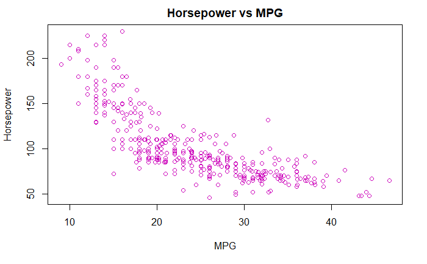

```r
# Relation between mpg and horsepower

plot(Auto$horsepower~Auto$mpg, col = 6, main = "Horsepower vs MPG", xlab = "MPG", ylab = "Horsepower")
```

**Cars with lower MPG have higher horsepower.**

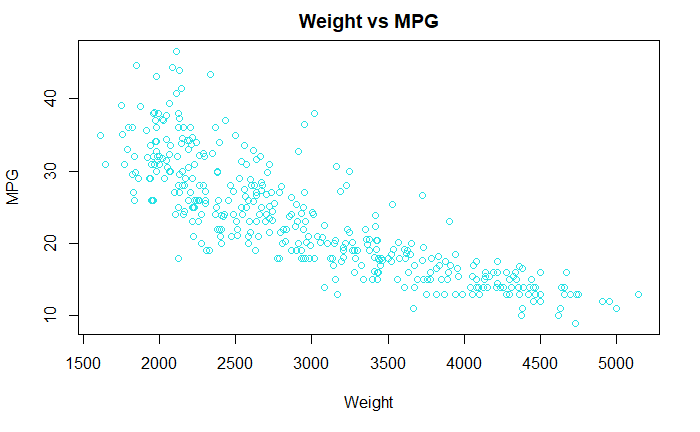

```r
# Relation between MPG and weight.

plot(Auto$mpg~Auto$weight, col = 5, xlab = "Weight", ylab = "MPG", main = "Weight vs MPG")
```

**Cars with higher weight have lower MPG.**

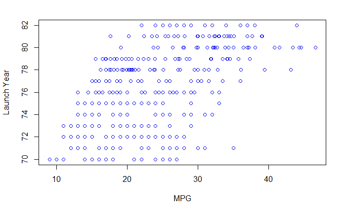

```r
plot(Auto$mpg, Auto$year, col = "blue2", xlab = "MPG", ylab = "Launch Year")
```

**Cars are getting efficient over time.**

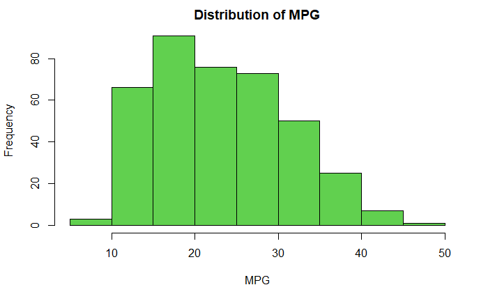

```r
hist(Auto$mpg,col=3, main = "Distribution of MPG", xlab = "MPG")
```

f. Suppose that we wish to predict gas mileage (`mpg`) on the basis of the other variables. Do your plots suggest that any of the other variables might be useful in predicting `mpg`? Justify your answer.